# Ocean acidification reduces skeletal density in spines of the Hawaiian collector urchin, *Tripneustes gratilla*.

Emily E. Sesno, Keisha Bahr, Ariana S. Huffmyer, Judith D. Lemus

# Setup

Set up workspace, load data, and load required packages.

```r
rm(list=ls(all=TRUE))

results <- read.csv("Data/Urchin_ClimateChange_Data.csv", header=T, na.strings="NA")

library("lme4") #linear mixed modeling
library("lmtest") #linear mixed modeling
library("lmerTest") #calculate p-values in models
library("car") #levenes tests
library("emmeans") #post-hoc tests
library("lsmeans") #post-hoc tests
library("plotrix") #calculate std.error
library("plyr")  #splitting, applying, and combining data
library("dplyr")
library("cowplot") #grid plotting and arrange plots
library("effects") #plot effects of modeling
library("MuMIn")
library("car") #levenes tests, Anova, qqPlots,
library("tidyverse")
library("stats")
library("onewaytests") #allows for Welch test with unequal variances (spine lengths)
library("stats")
library("effsize")
library("FSA")
library("rcompanion")
library("broom") #turns model output into data frames
library("kableExtra") #makes data tables easier to read
library("tidyverse")
```

# Approach:

```
1) Build and run model
2) Check for normality of residuals
3) Check for homogeniety of variance of residuals
4) Look at model summary
5) Run anova to check for significance of main effects
```

# Analysis:

1. Environmental Conditions and Manipulations:
   1. Calculate means
   2. Check environmental manipulations with ANOVAs for treatments
   3. Figure 1: Temp over time
   4. Figure 2: pH over time
2. Urchin Diameters:
   1. Calculate diameter means for:
      1. Day -24
      2. Day -13 iii.Day 1
      3. Day 126
      4. Table 3: Diameter Means
   2. Check for differences in urchin diameters from different tanks on Day 1
3. Response Analyses:
   1. Growth (%)
      1. Growth Analysis
      2. Figure 3: Growth Interaction Plot
   2. Calcification Ratio
      1. Calcification Analysis at the Tips
      2. Calcification Analysis at the Bases
      3. Figure 4: Calcification Interaction Plot
   3. Spine Loss (count)
      1. Spine Loss Analysis
      2. Figure 5: Spine Loss Interaction Plot

## 1. Environmental Conditions and Manipulations:

### a. Calculate environmental means

##### Table 1: Environmental Means

```r
EnviroMean <-
  results %>%
    select("Day", "Temperature", "pH", "Temp","pHspec", "pCO2out", "AlkTotal") %>%
    filter(Day >= "1", Day <= "123") %>%
    drop_na(Day) %>%
    group_by(Temperature, pH) %>%
    summarise(mean_T = mean(Temp, na.rm = T),
              se_T = sd(Temp, na.rm = T)/sqrt(6),
              min_T = min(Temp, na.rm = T),
              max_T = max(Temp, na.rm = T),
              mean_pH = mean(pHspec, na.rm = T),
              se_pH = sd(pHspec, na.rm = T)/sqrt(6),
              mean_pCO2 = mean(pCO2out, na.rm = T),
              se_pCO2 = sd(pCO2out, na.rm = T)/sqrt(6),
              mean_AlkTotal = mean(AlkTotal, na.rm = T),
              se_AlkTotal = sd(AlkTotal, na.rm = T)/sqrt(6))

EnviroMean %>%
  kbl(caption = "Table 1: Experimental treatments and environmental conditions (mean +/- standard error) of the 126-day experiment.") %>%
  kable_classic_2() %>%
  kable_styling(c("striped", "hover"), full_width = F, html_font= "Times New Roman")
```

Table 1: Experimental treatments and environmental conditions (mean +/- standard error) of the 126-day experiment.

| Temperature | pH | mean_T | se_T | min_T | max_T | mean_pH | se_pH | mean_pCO2 | se_pCO2 | mean_AlkTotal | se_AlkTotal |
| --- | --- | --- | --- | --- | --- | --- | --- | --- | --- | --- | --- |
| ambient | acidified | 24.79000 | 0.8869310 | 22.07 | 27.36 | 7.644120 | 0.0101512 | 1082.9250 | 65.31879 | 2142.000 | 112.494347 |
| ambient | ambient | 24.78429 | 0.8856820 | 22.09 | 27.40 | 7.961042 | 0.0146725 | 480.8325 | 22.56737 | 2181.872 | 5.679540 |
| heated | acidified | 26.73429 | 0.8269073 | 23.75 | 29.38 | 7.662486 | 0.0129196 | 1106.5750 | 77.15382 | 2137.082 | 123.057409 |
| heated | ambient | 26.70434 | 0.8184090 | 23.82 | 29.34 | 7.956690 | 0.0141496 | 524.3757 | 20.91815 | 2180.797 | 5.838938 |

### b. Check environmental manipulations with ANOVAs

```r
Environmental <-
  results %>%
    select("Day", "Temp", "pH", "Temperature","pHspec","Header", "TankID") %>%
    filter(Day >= "1", Day != "126") #use only days from start of experiment when desired conditions were reached


#temp between high and ambient temp
summary(aov(Temp ~ Temperature, data=Environmental)) #temperature was different between high and ambient treatment

#pH between high and ambient co2
summary(aov(pHspec ~ pH, data=Environmental)) #pH was different between high and ambient co2 treatments



##HEADERS
#temp between headers in high
aov1<- Environmental %>%
  filter(Temperature=="heated")

summary(aov(Temp ~ as.factor(Header), data=aov1)) #not different between headers

#temp between headers in ambient temp
aov2<- Environmental %>%
  filter(Temperature=="ambient")

summary(aov(Temp ~ as.factor(Header), data=aov2)) #not different between headers

#pH between headers in acidified
aov3<- Environmental %>%
  filter(pH=="acidified")

summary(aov(pHspec ~ as.factor(Header), data=aov3)) #not different between headers

#pH between headers in ambient pH
aov4<- Environmental %>%
  filter(pH=="ambient")

summary(aov(pHspec ~ as.factor(Header), data=aov4)) #not different between headers


##TANKS
#temp between tanks in high temp
aov1<- Environmental %>%
  filter(Temperature=="heated")

summary(aov(Temp ~ as.factor(TankID), data=aov1)) #not different between heated tanks

#temp between tanks in ambient temp
aov2<- Environmental %>%
  filter(Temperature=="ambient")

summary(aov(Temp ~ as.factor(TankID), data=aov2)) #not different between ambient tanks

#pH between tanks in acidified
aov3<- Environmental %>%
  filter(pH=="acidified")

summary(aov(pHspec ~ as.factor(TankID), data=aov3)) #not different between tanks in acidified

#pH between headers in ambient pH
aov4<- Environmental %>%
  filter(pH=="ambient")

summary(aov(pHspec ~ as.factor(TankID), data=aov4)) #not different between headers
```

##### Table 2: Results of ANOVA for environmental

| Treatment Comparison | Pr(>F) |
| --- | --- |
| Heated v. Ambient | <0.001 |
| Acidified v. Ambient | <0.001 |
| Ambient temp headers | 0.998 |
| Heated headers | 0.842 |
| Ambient pH headers | 0.129 |
| Acidified headers | 0.150 |
| Ambient temp tanks | 1.000 |
| Heated tanks | 0.999 |
| Ambient pH tanks | 0.675 |
| Acidified tanks | 0.888 |

### c. Figure 1: Temperature over time

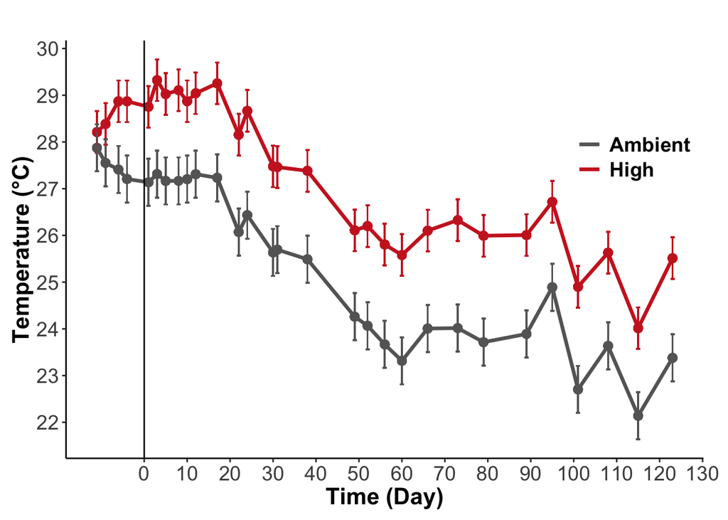

```r
tempsummary<-results %>%
  select("Day", "Temperature", "Temp") %>%
  drop_na(Temp) %>%
  group_by(Day, Temperature) %>%
  mutate(meanT = mean(Temp)) %>%
  group_by(Temperature) %>%
  mutate(sd = sd(Temp)) %>%
  mutate(se = sd/sqrt(12))

tempplot<-ggplot(data=tempsummary, aes(Day, meanT, color = Temperature)) +
    geom_point(size = 2.5, show.legend=FALSE) +
    geom_errorbar(aes(ymin = meanT-se, ymax = meanT+se)) +
    geom_line(size=1.2) +
    geom_vline(xintercept=0) +
    scale_x_continuous(name="Time (Day)", breaks = seq(0,130, by = 10)) +
    scale_y_continuous(name="Temperature (°C)", breaks = seq(20,30, by = 1)) +
    scale_shape_discrete(name = NULL,
                         labels = c("Ambient", "High"))+
    scale_color_manual(name = NULL,
                       values = c("gray40", "firebrick3"),
                       labels = c("Ambient", "High")) +
    ggtitle("")+
    theme_classic() +
    theme(plot.margin=unit(c(0.3,0.6,0.3,0.3), "cm"))+
    theme(legend.margin = margin(0),
          legend.position = c(.98,.8),
          legend.justification = c("right", "top"),
          legend.background = element_blank(),
          axis.title = element_text(size = 16, face="bold"),
          axis.text = element_text(size = 14),
          plot.title = element_text(size=16, face="bold"),
          legend.text = element_text(size=14, face="bold"));tempplot
```

```r
#ggsave(filename="Figures/20200611/TempFig1.png", plot=tempplot, dpi=300, width=7, height=5, units="in")
```

### d. Figure 2: pH over time

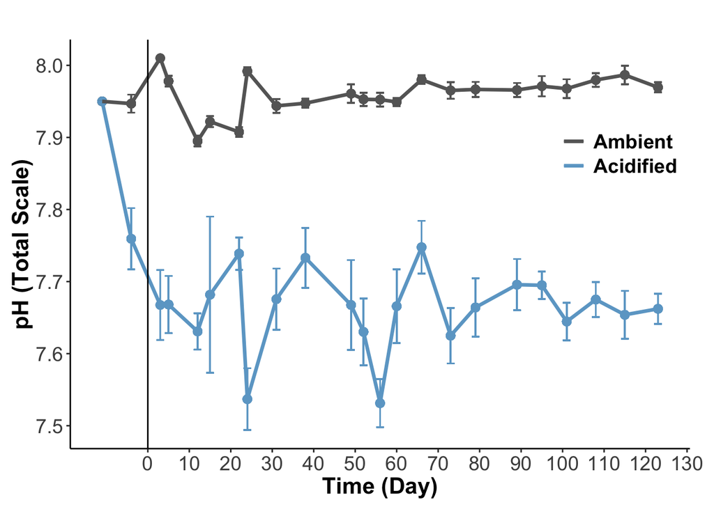

```r
pHsummary<-results %>%
  select("Day","pH", "pHspec") %>%
  drop_na(pHspec) %>%
  group_by(Day, pH) %>%
  mutate(meanpH = mean(pHspec)) %>%
  group_by(pH, meanpH) %>%
  mutate(sd = sd(pHspec)) %>%
  mutate(se = sd/sqrt(12))


pHplot<-ggplot(data=pHsummary, aes(Day, meanpH, color = pH)) +
    geom_point(size = 2.5, show.legend=FALSE) +
    geom_errorbar(aes(ymin = meanpH-sd, ymax = meanpH+sd)) +
    geom_line(size=1.2) +
    geom_vline(xintercept=0) +
    scale_x_continuous(name="Time (Day)", breaks = seq(0,130, by = 10)) +
    scale_y_continuous(name="pH (Total Scale)", breaks = seq(7.5,8.1, by = .1)) +
    scale_shape_discrete(name = NULL,
                         labels = c("Low pH", "High pH"))+
    scale_color_manual(name = NULL,
                       values = c("skyblue3", "gray40"),
                       labels = c("Acidified", "Ambient"),
                       guide = guide_legend(reverse = TRUE)) +
    ggtitle("")+
    theme_classic() +
    theme(plot.margin=unit(c(0.3,0.6,0.3,0.3), "cm"))+
    theme(legend.margin = margin(0),
          legend.position = c(.98,.8),
          legend.justification = c("right", "top"),
          legend.background = element_blank(),
          axis.title = element_text(size = 16, face="bold"),
          axis.text = element_text(size = 14),
          plot.title = element_text(size=16, face="bold"),
          legend.text = element_text(size=14, face="bold"));pHplot
```

```r
#ggsave(filename="Figures/20200611/pHFig1.png", plot=pHplot, dpi=300, width=7, height=5, units="in")
```

## 2. Urchin Diameters:

### a. Calculate diameter means

#### i. Day -24

Assemble data for diameters of initial collection of urchins from hatchery and calculate mean

```r
##Initial Collection = Day -24
InitialDiameter <-
  #seperate out the initial sizes of urchins on day -24 after initial collection.
  results %>%
    select("Day", "Diam1", "Diam2", "TankID", "Temperature", "pH", "Treatment") %>%
    filter(TankID != "8t" ) %>%
      #remove urchin number 8 which died halfway through
    drop_na(Diam1, Diam2) %>%
    gather(key = "1or2", value = "Diameter", "Diam1", "Diam2") %>%
      #gather Diam1 and Diam2 into single column in order to make number of levels of each grouping factor < number of observations (as per error message previously recieved)
    filter(Day == "-24") %>%
      #sizes on day -24
    select("TankID", "Diameter", "Temperature", "pH", "Treatment")


InitialMean <- mean(InitialDiameter$Diameter)
InitialSE <- sd(InitialDiameter$Diameter)/sqrt(23)

InitialMean
InitialSE
```

#### ii. Day -13

Assemble Data for diameters of acclimated urchins before conditioning and calculate mean

```r
##After acclimating before ramp up = Day-13

AcclimatedDiameter <-
  #seperate out the initial sizes of urchins on day -24, when desired conditions were met.
  results %>%
    select("Day", "Diam1", "Diam2", "TankID", "Temperature", "pH", "Treatment") %>%
    filter(TankID != "8t" ) %>%
      #remove urchin number 8 which died halfway through
    drop_na(Diam1, Diam2) %>%
    gather(key = "1or2", value = "Diameter", "Diam1", "Diam2") %>%
      #gather Diam1 and Diam2 into single column in order to make number of levels of each grouping factor < number of observations (as per error message previously recieved)
    filter(Day == "-13") %>%
      #sizes on day -24
    select("TankID", "Diameter", "Temperature", "pH", "Treatment")


AcclimatedMean <- mean(AcclimatedDiameter$Diameter)
AcclimatedSE <- sd(AcclimatedDiameter$Diameter)/sqrt(23)

AcclimatedMean
AcclimatedSE
```

#### iii. Day 1

Assemble Data for diameters on day 1 of experiment when desired conditions were reached

```r
##After ramp up and desired conditions are reached to begin experiment = Day 1

Day1Diameter <-
  #seperate out the initial sizes of urchins on day 1, when desired conditions were met.
  results %>%
    select("Day", "Diam1", "Diam2", "TankID", "Temperature", "pH", "Treatment") %>%
    filter(TankID != "8t" ) %>%
      #remove urchin number 8 which died halfway through
    drop_na(Diam1, Diam2) %>%
    gather(key = "1or2", value = "Diameter", "Diam1", "Diam2") %>%
      #gather Diam1 and Diam2 into single column in order to make number of levels of each grouping factor < number of observations (as per error message previously recieved)
    filter(Day == "1") %>%
      #sizes on day 1
    select("TankID", "Diameter", "Temperature", "pH", "Treatment")


Day1Mean <- mean(Day1Diameter$Diameter)
Day1SE <- sd(Day1Diameter$Diameter)/sqrt(23)

Day1Mean
Day1SE
```

#### iv. Day 126

Assemble Data for diameters on day 126 of experiment after full growth

```r
##After ramp up and desired conditions are reached to begin experiment = Day 1

Day126Diameter <-
  #seperate out the initial sizes of urchins on day 1, when desired conditions were met.
  results %>%
    select("Day", "Diam1", "Diam2", "TankID", "Temperature", "pH", "Treatment") %>%
    filter(TankID != "8t" ) %>%
      #remove urchin number 8 which died halfway through
    drop_na(Diam1, Diam2) %>%
    gather(key = "1or2", value = "Diameter", "Diam1", "Diam2") %>%
      #gather Diam1 and Diam2 into single column in order to make number of levels of each grouping factor < number of observations (as per error message previously recieved)
    filter(Day == "126") %>%
      #sizes on day 1
    select("TankID", "Diameter", "Temperature", "pH", "Treatment")


Day126Mean <- mean(Day126Diameter$Diameter)
Day126SE <- sd(Day126Diameter$Diameter)/sqrt(23)

Day126Mean
Day126SE
```

##### v. Table 3: Urchin diameter means

| Day | Mean Urchin Diameter (mm) | se |
| --- | --- | --- |
| -24 | 7.53 | 0.15 |
| -13 | 10.38 | 0.23 |
| 1 | 16.03 | 0.36 |
| 126 | 70.52 | 1.43 |

### b. Results of linear mixed model effect on diameter (day 1)

```r
Day1Mod <- lmer(Diameter ~ Temperature*pH + (1|TankID), data=Day1Diameter)
anova(Day1Mod, type = 2)
```

```
## Type II Analysis of Variance Table with Satterthwaite's method
##                 Sum Sq Mean Sq NumDF DenDF F value  Pr(>F)
## Temperature    0.04177 0.04177     1    19  0.1922 0.66606
## pH             0.38094 0.38094     1    19  1.7525 0.20128
## Temperature:pH 0.89969 0.89969     1    19  4.1389 0.05611 .
## ---
## Signif. codes:  0 '***' 0.001 '**' 0.01 '*' 0.05 '.' 0.1 ' ' 1
```

Check assumptions of diameter model (Day 1)

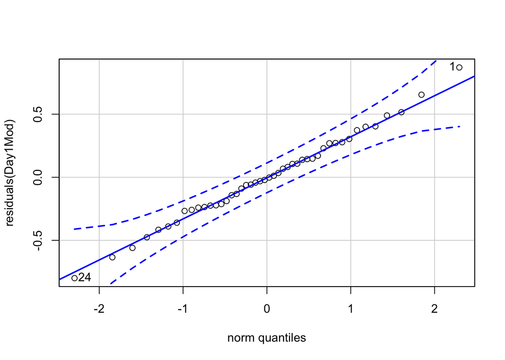

```r
#check assumptions
# 1. Normality of residuals
qqPlot(residuals(Day1Mod)) #not super normal but... see below
```

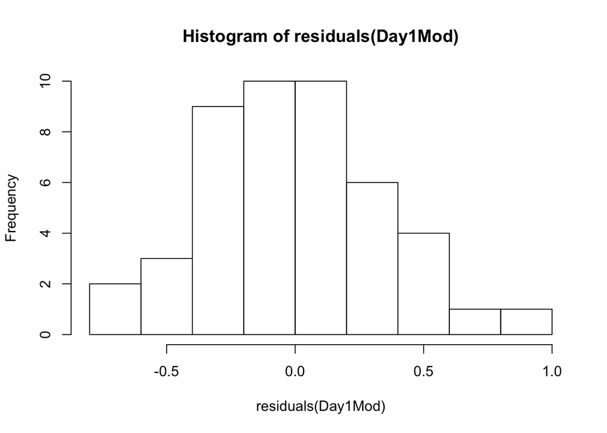

```r
shapiro.test(residuals(Day1Mod)) #passes
hist(residuals(Day1Mod)) #looks normalish
```

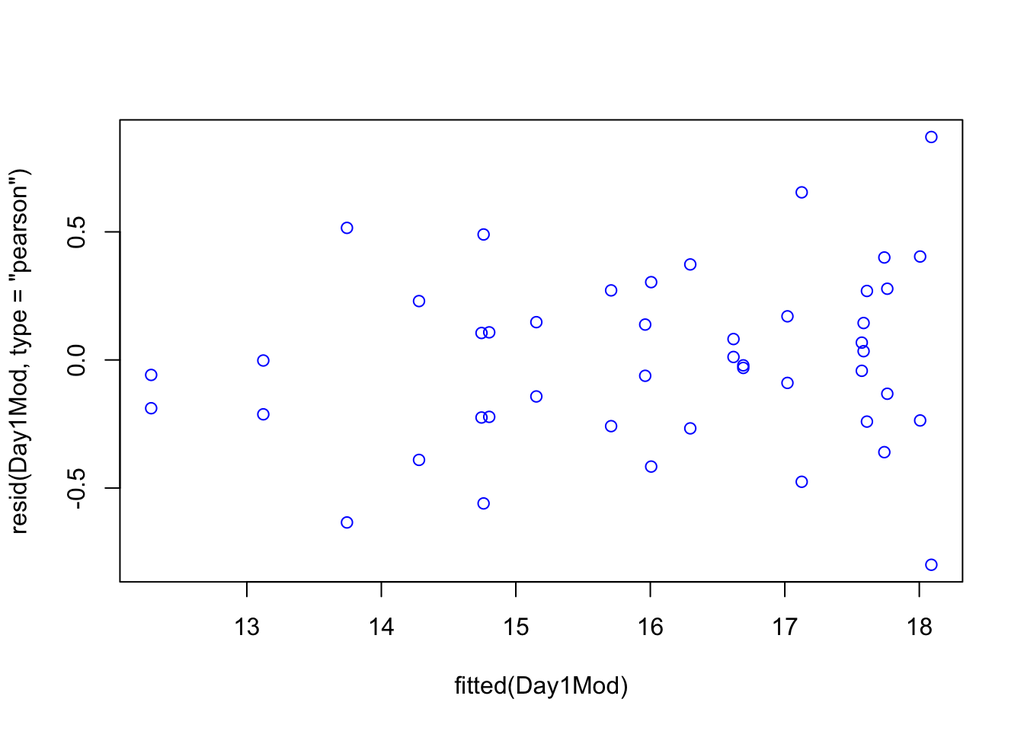

```r
# 2. Equal variances
leveneTest(residuals(Day1Mod)~InitialDiameter$Treatment) #Passes
plot(fitted(Day1Mod),resid(Day1Mod,type="pearson"),col="blue")
```

## 3. Response Analysis

### a. Growth

#### i. Growth Analysis

Assemble data and calculate means using day 1 as initial diameter and calculate means

```r
### GROWTH MODEL 1: using day 1 as the first official day of experiment when desired environmental conditions were met (24 days after getting urchins. In that 24 days, they were acclimated and then conditions ramped up)

Initial <-
  #seperate out the initial sizes of urchins on day 1, when desired conditions were met to standardize growth to this measurement.
  results %>%
    select("Day", "Treatment", "Temperature", "pH", "Diam1", "Diam2", "TankID") %>%
    filter(TankID != "8t" ) %>%
      #remove urchin number 8 which died halfway through
    drop_na(Diam1, Diam2) %>%
    gather(key = "1or2", value = "Diameter", "Diam1", "Diam2") %>%
      #gather Diam1 and Diam2 into single column in order to make number of levels of each grouping factor < number of observations (as per error message previously recieved)
    filter(Day == "1") %>%
      #sizes on day 1
    select("Temperature", "pH", "Diameter", "TankID")


Final <-
  #seperate out the final sizes of urchins on day 126
   results %>%
    select("Day", "Treatment", "Temperature", "pH", "Diam1", "Diam2", "TankID") %>%
    drop_na(Diam1, Diam2) %>%
    gather(key = "1or2", value = "Diameter", "Diam1", "Diam2") %>%
      #gather Diam1 and Diam2 into single column
    filter(Day == "126") %>%
      #filter for sizes on day 126
    select("Temperature", "pH", "Diameter","TankID")


Growth <-
  #create column that is growth
  bind_cols(Initial, Final) %>%
    #binds initial (Diameter) and final (Diameter1) sizes to calculate growth
  mutate(Growth = ((Diameter1 - Diameter)/Diameter*100)) %>%
    #add column for growth calculation
  select("Growth")


resultsGrow <-
  #table of initial and final size data
  results %>%
    select("Day", "Treatment", "Temperature", "pH", "TankID", "Diam1", "Diam2") %>%
    drop_na(Diam1, Diam2) %>%
    gather(key = "1or2", value = "Diameter", "Diam1", "Diam2") %>%
    filter(Day == "126")
resultsGrow <- bind_cols(resultsGrow, Growth)
#combines table of initial and final with growth information

#Figure out means of each treatment group
resultsGrow %>%
  dplyr::group_by(Temperature, pH) %>%
  dplyr::summarise(mean = mean(Growth), s.e. = se(Growth)) %>%

  kbl(caption = "Table 6: Growth means +/- se after 126 days") %>%
  kable_classic_2() %>%
  kable_styling(c("striped", "hover"), full_width = F, html_font= "Times New Roman")
```

Table 6: Growth means +/- se after 126 days

| Temperature | pH | mean | s.e. |
| --- | --- | --- | --- |
| ambient | acidified | 326.5950 | 16.290140 |
| ambient | ambient | 323.1710 | 10.963618 |
| heated | acidified | 352.0342 | 15.002253 |
| heated | ambient | 376.3414 | 7.147267 |

```r
#LMM for growth:
modGrow <-
  resultsGrow %>%
  aov(Growth~ Temperature * pH, data=.)

#Need to decide on model type that we want to use.

summary(modGrow)
```

```
##                Df Sum Sq Mean Sq F value  Pr(>F)
## Temperature     1  16750   16750   8.257 0.00634 **
## pH              1   1096    1096   0.540 0.46642
## Temperature:pH  1   2197    2197   1.083 0.30396
## Residuals      42  85202    2029
## ---
## Signif. codes:  0 '***' 0.001 '**' 0.01 '*' 0.05 '.' 0.1 ' ' 1
```

```r
aov(modGrow, type="II") #anova{stats}.Compute analysis of variance (or deviance) tables for one or more fitted model objects. Produces Type II Analysis of Variance Table with Satterthwaite's method.
```

```
## Call:
##    aov(formula = modGrow, type = "II")
##
## Terms:
##                 Temperature       pH Temperature:pH Residuals
## Sum of Squares     16749.50  1095.91        2197.19  85201.61
## Deg. of Freedom           1        1              1        42
##
## Residual standard error: 45.04009
## Estimated effects may be unbalanced
```

Check assumptions for growth model

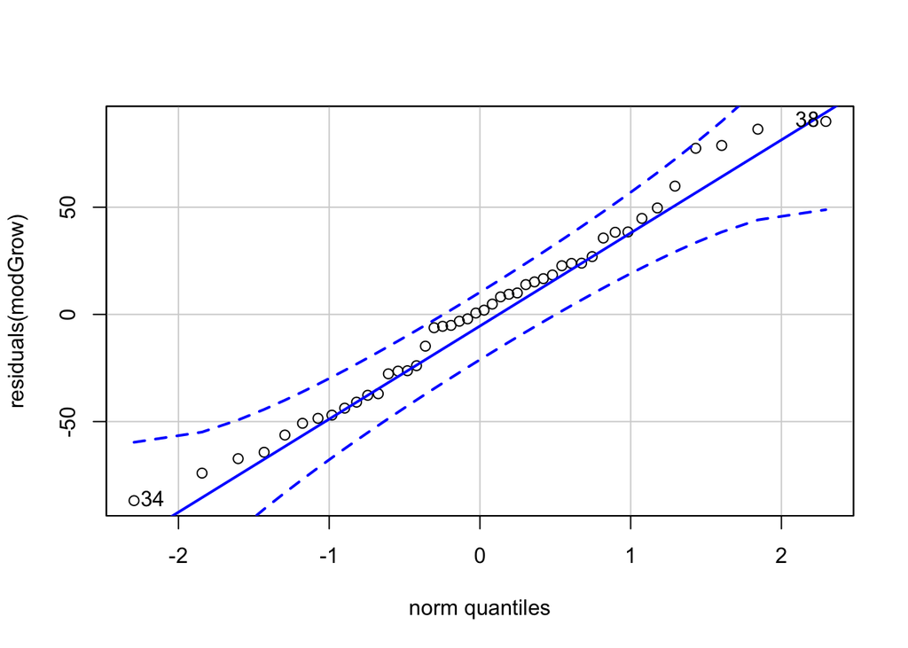

```
## [1] 38 34
```

```r
## ASSSUMPTIONS
# 1. Normality of residuals
qqPlot(residuals(modGrow))
```

```r
shapiro.test(residuals(modGrow)) #passes
```

```
##
##  Shapiro-Wilk normality test
##
## data:  residuals(modGrow)
## W = 0.98242, p-value = 0.7064
```

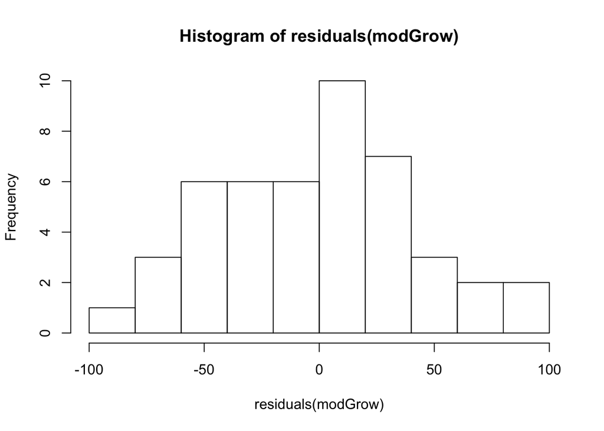

```r
hist(residuals(modGrow)) #looks normal
```

```r
# 2. Equal variances
leveneTest(residuals(modGrow)~resultsGrow$Treatment) #Passes
```

```
## Levene's Test for Homogeneity of Variance (center = median)
##       Df F value  Pr(>F)
## group  3  2.3134 0.08975 .
##       42
## ---
## Signif. codes:  0 '***' 0.001 '**' 0.01 '*' 0.05 '.' 0.1 ' ' 1
```

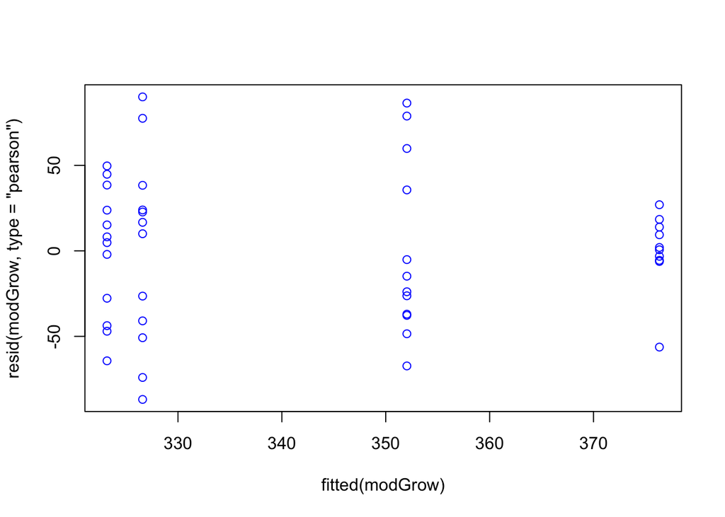

```r
plot(fitted(modGrow),resid(modGrow,type="pearson"),col="blue")
```

#### ii. Growth Interaction Plot

[figure not shown]

```r
growthsummary<-results %>%
  filter(Day==126) %>%
  select("pH", "Temperature","Growth") %>%
  drop_na(Growth) %>%
  mutate(meanPct = Growth*100) %>%
  group_by(pH, Temperature) %>%
  summarise(mean = mean(meanPct),
            N = length(meanPct),
            se = std.error(meanPct))


growthplot<-ggplot(data=growthsummary, aes(x=Temperature, y=mean, color = pH, group=interaction(Temperature,pH))) +
    geom_point(size = 3,  position=position_dodge(0.1)) +
    geom_line(aes(group=pH),  position=position_dodge(0.1)) +
    xlab("Temperature Treatment") +
    ylab("Total Growth (%)")+
    geom_errorbar(aes(ymin = mean-se, ymax = mean+se, width = 0.1), position=position_dodge(0.1)) +
    theme_bw() +
    scale_x_discrete(limits=c("ambient", "heated"),
                     label=c("Ambient", "High"))+
    scale_colour_manual(name = "pH Treatment",
                        values = c("skyblue3", "gray40"),
                        labels = c("Acidified", "Ambient"),
                        guide = guide_legend(reverse = TRUE)) +
    geom_text(x=1.5, y=125, label="p(pH)=0.61", size=6, color="darkgray") +
    geom_text(x=1.5, y=100, label="p(Temperature)=0.06", size=6, color="darkgray") +
    geom_text(x=1.5, y=75, label="p(Interaction)=0.47", size=6, color="darkgray") +
    ylim(0,450)+
    theme_classic()+
    theme(legend.position = "right",
          legend.background = element_blank(),
          axis.title = element_text(size = 16, face="bold"),
          axis.text = element_text(size = 14),
          plot.title = element_text(size=16, face="bold"),
          legend.text = element_text(size=14),
          legend.title = element_text(size=16, face="bold"));growthplot
```

```r
#ggsave(filename="Figures/20200611/GrowthFig.png", plot=growthplot, dpi=300, width=8, height=6, units="in")
```

### b. Calcification Ratio

#### i. Calcification Ratio Analysis at the tips

Assemble data for chosen spine tips (distal end)

```r
### Model 1: calcification at the tips of spines

resultsTip <-
  #create data using only the SEM images of the tips of spines.
  results %>%
  select ("Treatment", "Temperature", "pH", "PartOfSpine", "Chosen", "RatioSEM", "TankID") %>%
    #selects for desired variables. PartOfSpine is tip or base, Chosen indicates which side of the image (arbitrary) is selected for (aka has no dust)
  drop_na(RatioSEM) %>%
  filter(Chosen == "yes", PartOfSpine == "Tip")
    #filters only for tips and chosen side. No dusty images to be analyzed.
```

Results for spine tips with linear mixed model

```r
#LMM for calcification at the tips of spines
modTip <-
  resultsTip %>%
  lmer(RatioSEM ~ Temperature * pH + (1|TankID), data = .)

summary(modTip)
```

```
## Linear mixed model fit by REML. t-tests use Satterthwaite's method [
## lmerModLmerTest]
## Formula: RatioSEM ~ Temperature * pH + (1 | TankID)
##    Data: .
##
## REML criterion at convergence: 64.1
##
## Scaled residuals:
##      Min       1Q   Median       3Q      Max
## -1.76413 -0.74507 -0.02052  0.63045  2.07630
##
## Random effects:
##  Groups   Name        Variance Std.Dev.
##  TankID   (Intercept) 0.0000   0.0000
##  Residual             0.1356   0.3682
## Number of obs: 67, groups:  TankID, 23
##
## Fixed effects:
##                             Estimate Std. Error       df t value Pr(>|t|)
## (Intercept)                  1.69118    0.08930 63.00000  18.938   <2e-16
## Temperatureheated           -0.06662    0.12453 63.00000  -0.535   0.5945
## pHambient                   -0.07462    0.12453 63.00000  -0.599   0.5512
## Temperatureheated:pHambient  0.30557    0.18089 63.00000   1.689   0.0961
##
## (Intercept)                 ***
## Temperatureheated
## pHambient
## Temperatureheated:pHambient .
## ---
## Signif. codes:  0 '***' 0.001 '**' 0.01 '*' 0.05 '.' 0.1 ' ' 1
##
## Correlation of Fixed Effects:
##             (Intr) Tmprtr pHmbnt
## Tempertrhtd -0.717
## pHambient   -0.717  0.514
## Tmprtrhtd:H  0.494 -0.688 -0.688
## convergence code: 0
## boundary (singular) fit: see ?isSingular
```

```r
anova(modTip, type="II") #anova{stats}.Compute analysis of variance (or deviance) tables for one or more fitted model objects. Produces Type II Analysis of Variance Table with Satterthwaite's method.
```

```
## Type II Analysis of Variance Table with Satterthwaite's method
##                 Sum Sq Mean Sq NumDF DenDF F value  Pr(>F)
## Temperature    0.10158 0.10158     1    63  0.7492 0.39000
## pH             0.08185 0.08185     1    63  0.6038 0.44006
## Temperature:pH 0.38685 0.38685     1    63  2.8534 0.09612 .
## ---
## Signif. codes:  0 '***' 0.001 '**' 0.01 '*' 0.05 '.' 0.1 ' ' 1
```

Check assumptions for calcification at tip model.

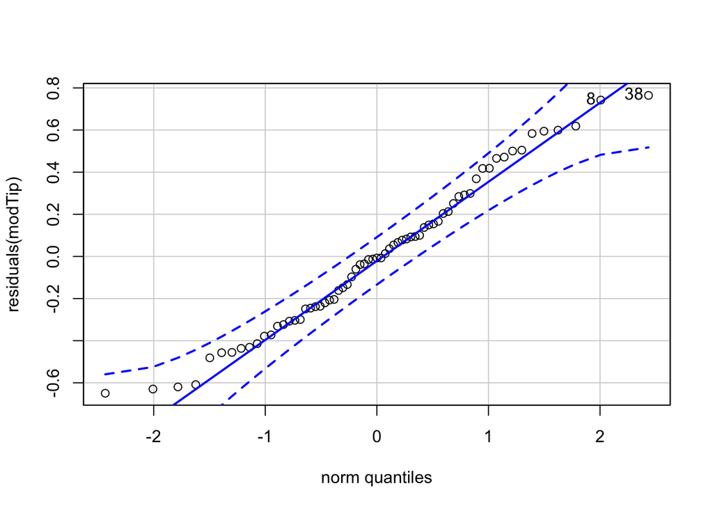

```
## [1] 38  8
```

```r
## ASSSUMPTIONS
# 1. Normality of residuals
qqPlot(residuals(modTip)) #Normal
```

```r
shapiro.test(residuals(modTip)) #Pass
```

```
##
##  Shapiro-Wilk normality test
##
## data:  residuals(modTip)
## W = 0.97737, p-value = 0.2605
```

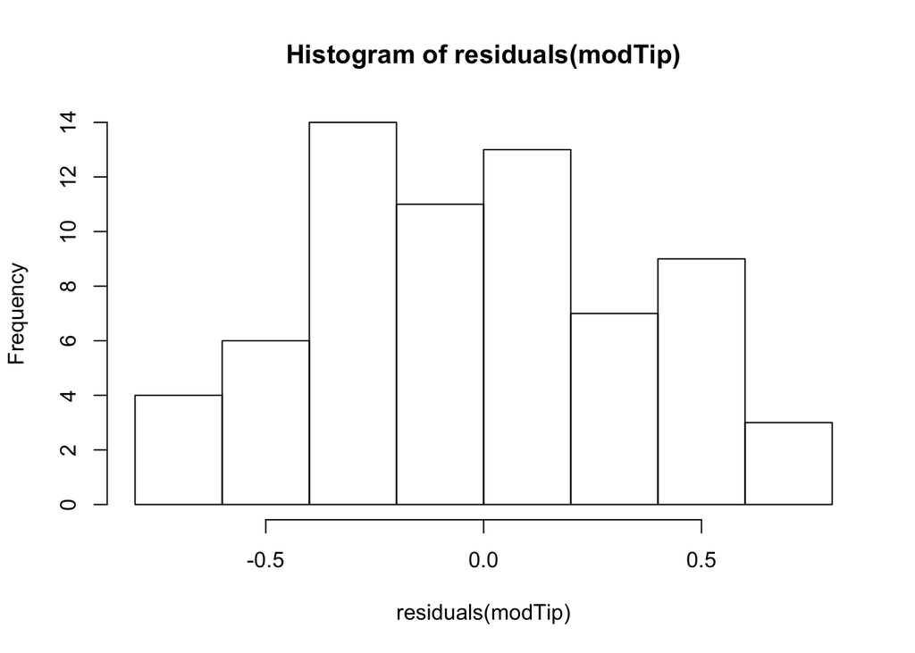

```r
hist(residuals(modTip))
```

```r
# 2. Equal variances
leveneTest(residuals(modTip)~resultsTip$Treatment) #Pass
```

```
## Levene's Test for Homogeneity of Variance (center = median)
##       Df F value Pr(>F)
## group  3  0.4545  0.715
##       63
```

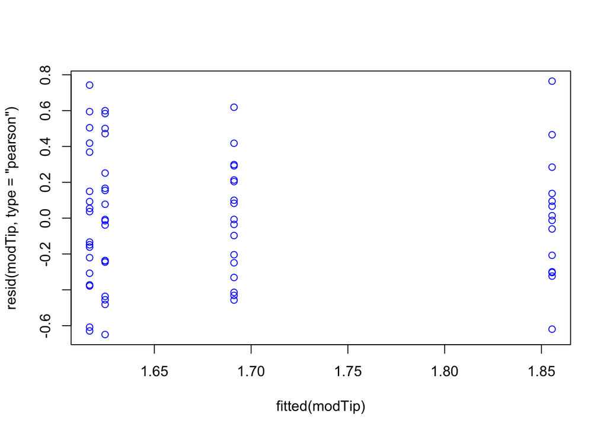

```r
plot(fitted(modTip),resid(modTip,type="pearson"),col="blue")
```

#### ii. Calcification Ratio Analysis at the base

Assemble data for chosen spine bases (proximal end)

```r
### Model 2: calcification in the base of the spines

resultsBase <-
   #create data using only the SEM images of the base of spines.
  results %>%
  select ("Treatment", "Temperature", "pH", "PartOfSpine", "Chosen", "RatioSEM", "TankID") %>%
    #selects for desired variables. PartOfSpine is tip or base, Chosen indicates which side of the image (arbitrary) is selected for (aka has no dust)
  drop_na(RatioSEM) %>%
  filter(Chosen == "yes", PartOfSpine == "Base")
    #filters only for tips and chosen side. No dusty images to be analyzed.
```

Results for spine bases with linear mixed model

```r
#LMM for calcification at the tips of spines
modBase <-
  resultsBase %>%
  lmer(RatioSEM~ Temperature * pH + (1|TankID), data=.)

summary(modBase)
```

```
## Linear mixed model fit by REML. t-tests use Satterthwaite's method [
## lmerModLmerTest]
## Formula: RatioSEM ~ Temperature * pH + (1 | TankID)
##    Data: .
##
## REML criterion at convergence: 98.8
##
## Scaled residuals:
##     Min      1Q  Median      3Q     Max
## -1.5535 -0.6315 -0.1529  0.6918  1.9937
##
## Random effects:
##  Groups   Name        Variance Std.Dev.
##  TankID   (Intercept) 0.1303   0.3610
##  Residual             0.1597   0.3996
## Number of obs: 68, groups:  TankID, 23
##
## Fixed effects:
##                             Estimate Std. Error      df t value Pr(>|t|)
## (Intercept)                   2.1440     0.1749 18.8077  12.257 2.06e-10
## Temperatureheated             0.3566     0.2487 19.1707   1.434   0.1677
## pHambient                     0.6524     0.2474 18.8077   2.637   0.0163
## Temperatureheated:pHambient  -0.2224     0.3594 18.9804  -0.619   0.5434
##
## (Intercept)                 ***
## Temperatureheated
## pHambient                   *
## Temperatureheated:pHambient
## ---
## Signif. codes:  0 '***' 0.001 '**' 0.01 '*' 0.05 '.' 0.1 ' ' 1
##
## Correlation of Fixed Effects:
##             (Intr) Tmprtr pHmbnt
## Tempertrhtd -0.703
## pHambient   -0.707  0.497
## Tmprtrhtd:H  0.487 -0.692 -0.688
```

```r
anova(modBase, type="II") #anova{stats}.Compute analysis of variance (or deviance) tables for one or more fitted model objects. Produces Type III Analysis of Variance Table with Satterthwaite's method.
```

```
## Type II Analysis of Variance Table with Satterthwaite's method
##                 Sum Sq Mean Sq NumDF  DenDF F value   Pr(>F)
## Temperature    0.30743 0.30743     1 18.992  1.9251 0.181362
## pH             1.48873 1.48873     1 18.960  9.3223 0.006553 **
## Temperature:pH 0.06114 0.06114     1 18.980  0.3829 0.543424
## ---
## Signif. codes:  0 '***' 0.001 '**' 0.01 '*' 0.05 '.' 0.1 ' ' 1
```

Check assumptions for calcification at base model.

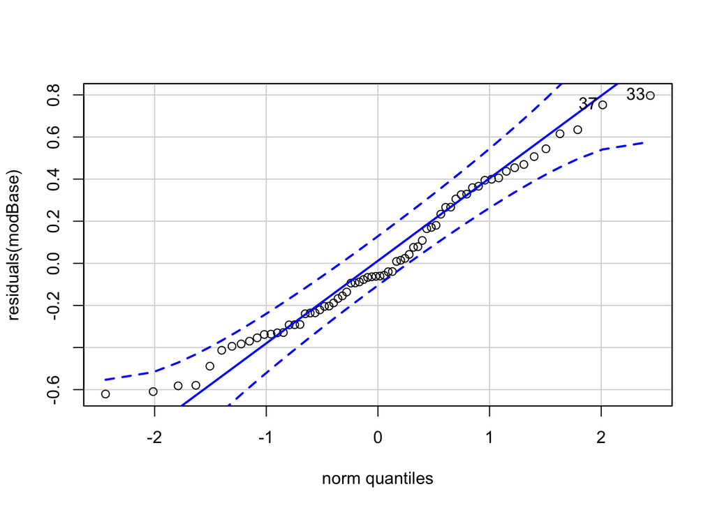

```
## [1] 33 37
```

```r
## ASSSUMPTIONS
# 1. Normality of residuals
qqPlot(residuals(modBase)) #Normal
```

```r
shapiro.test(residuals(modBase)) # Pass
```

```
##
##  Shapiro-Wilk normality test
##
## data:  residuals(modBase)
## W = 0.97304, p-value = 0.1472
```

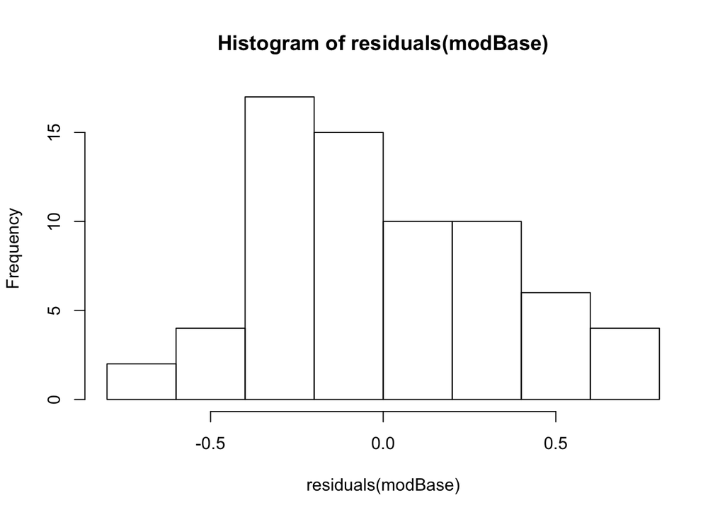

```r
hist(residuals(modBase))
```

```r
# 2. Equal variances
leveneTest(residuals(modBase)~resultsBase$Treatment) #Pass
```

```
## Levene's Test for Homogeneity of Variance (center = median)
##       Df F value Pr(>F)
## group  3   1.068  0.369
##       64
```

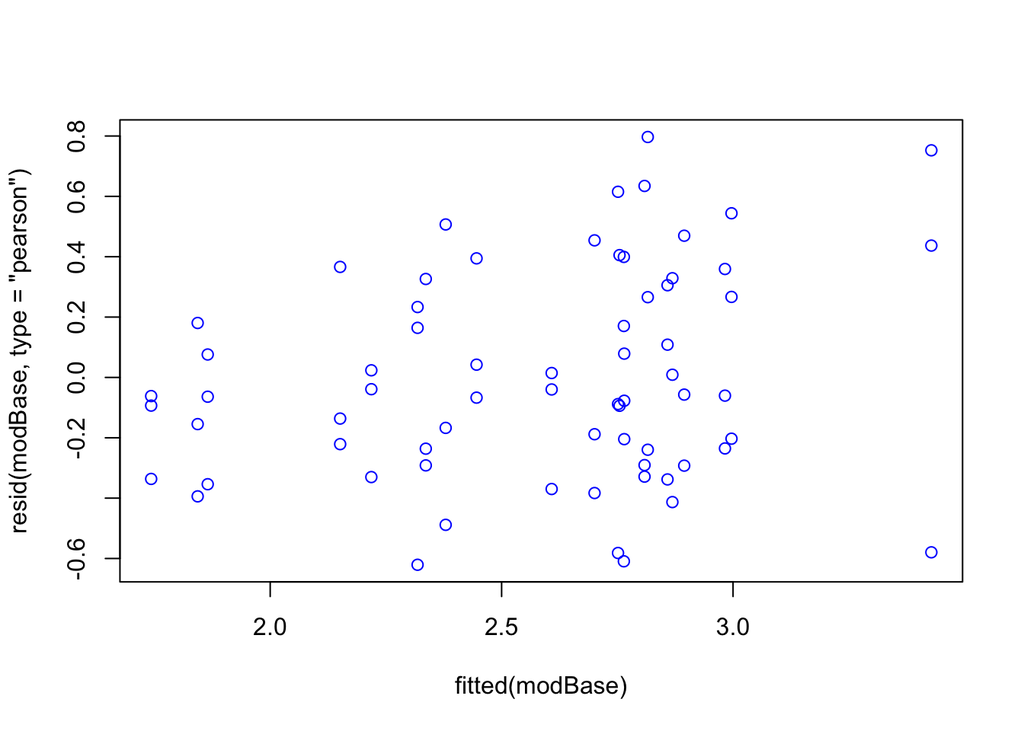

```r
plot(fitted(modBase),resid(modBase,type="pearson"),col="blue")
```

#### iii. Figure 4: Calcification Ratio Interaction Plot at tips and bases

Make Interaction plots for calcification at the base and the tip

[figure not shown]

```r
#### Tip and base calcification ratios

#base
basesummary<-results %>%
  select("Temperature","pH","RatioSEM", "PartOfSpine") %>%
  filter(PartOfSpine=="Base")%>%
  drop_na(RatioSEM) %>%
  group_by(pH, Temperature, PartOfSpine) %>%
  summarize(mean = mean(RatioSEM), se = std.error(RatioSEM), N = length(RatioSEM))

baseplot<- ggplot(data=basesummary, aes(x=Temperature, y=mean, color = pH, group=interaction(Temperature,pH))) +
    geom_point(size = 3,  position=position_dodge(0.1)) +
    geom_line(aes(group=pH),  position=position_dodge(0.1)) +
    xlab("Temperature Treatment") +
    ylab("Proximal Calcification Ratio")+
    ylim(1,3.5)+
    geom_errorbar(aes(ymin = mean-se, ymax = mean+se, width = 0.1), position=position_dodge(0.1)) +
    theme_bw() +
    scale_x_discrete(limits=c("ambient", "heated"),
                     label=c("Ambient", "High"))+
    scale_colour_manual(name = "pH Treatment",
                        values = c("skyblue3", "gray40"),
                        labels = c("Acidified", "Ambient"),
                        guide = guide_legend(reverse = TRUE)) +
    geom_text(x=1.5, y=1.6, label="p(pH)=0.002", size=6, color="black") +
    geom_text(x=1.5, y=1.4, label="p(Temperature)=0.16", size=6, color="darkgray") +
    geom_text(x=1.5, y=1.2, label="p(Interaction)=0.54", size=6, color="darkgray") +
    theme_classic()+
    theme(legend.position = "right",
          legend.background = element_blank(),
          axis.title = element_text(size = 16, face="bold"),
          axis.text = element_text(size = 14),
          plot.title = element_text(size=16, face="bold"),
          legend.text = element_text(size=14),
          legend.title = element_text(size=16, face="bold"));baseplot
```

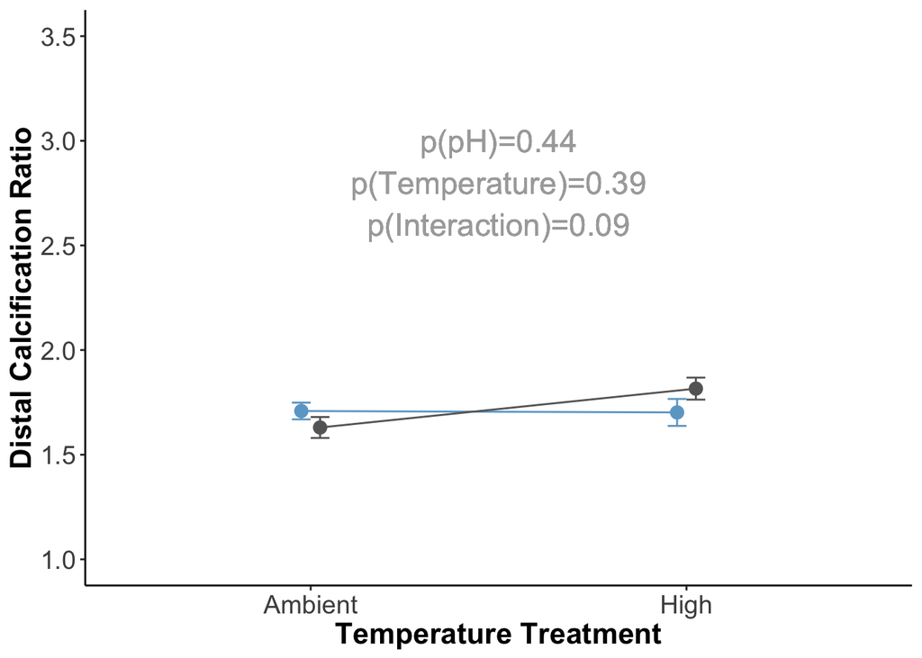

```r
#ggsave("CalcRatiobase.png", plot=baseplot, path = "/Users/emilysesno/Desktop/R_Analysis/R_Analysis/output",  width = 7, height = 5)

ggsave(filename="Figures/20200611/BaseCalcificationFig.png", plot=baseplot, dpi=300, width=8, height=6, units="in")

#tip
tipsummary<-results %>%
  select("Temperature","pH","RatioSEM", "PartOfSpine") %>%
  filter(PartOfSpine=="Tip")%>%
  drop_na(RatioSEM) %>%
  group_by(pH, Temperature, PartOfSpine) %>%
  summarize(mean = mean(RatioSEM), se = std.error(RatioSEM), N = length(RatioSEM))

tipplot<-ggplot(data=tipsummary, aes(x=Temperature, y=mean, color = pH, group=interaction(Temperature,pH))) +
    geom_point(size = 3,  position=position_dodge(0.1)) +
    geom_line(aes(group=pH),  position=position_dodge(0.1)) +
    xlab("Temperature Treatment") +
    ylab("Distal Calcification Ratio")+
    ylim(1,3.5)+
    geom_errorbar(aes(ymin = mean-se, ymax = mean+se, width = 0.1), position=position_dodge(0.1)) +
    theme_bw() +
    scale_x_discrete(limits=c("ambient", "heated"),
                     label=c("Ambient", "High"))+
    scale_colour_manual(name = "pH Treatment",
                        values = c("skyblue3", "gray40"),
                        labels = c("Acidified", "Ambient"),
                        guide = guide_legend(reverse = TRUE)) +
    geom_text(x=1.5, y=3.0, label="p(pH)=0.44", size=6, color="darkgray") +
    geom_text(x=1.5, y=2.8, label="p(Temperature)=0.39", size=6, color="darkgray") +
    geom_text(x=1.5, y=2.6, label="p(Interaction)=0.09", size=6, color="darkgray") +
    theme_classic()+
    theme(legend.position = "none", #removed the legend for the tip, so when we align them horizontally we only have one legend. But need to adjust the size so it is the same as base
          legend.background = element_blank(),
          axis.title = element_text(size = 16, face="bold"),
          axis.text = element_text(size = 14),
          plot.title = element_text(size=16, face="bold"),
          legend.text = element_text(size=14),
          legend.title = element_text(size=16, face="bold"));tipplot
```

```r
#ggsave(filename="Figures/20200611/TipCalcificationFig.png", plot=tipplot, dpi=300, width=8, height=6, units="in")
```

### c. Spine Loss

#### i. Spine Loss Analysis:

Assemble data for dropped spines

```r
## Number of loose spines counted at the bottom of tanks at the end of the experiment. These were either broken or shed. Note: these spines were not collected, just counted, so can not determine whether they were broken or shed.

resultsDropped <-
  #create data using only the needed variables.
  results %>%
  select ("Treatment", "Temperature", "pH", "SpineCount", "TankID") %>%
  drop_na(SpineCount) %>%
  group_by(pH) %>%
  mutate(mean = mean(SpineCount),
         se = std.error(SpineCount))
```

Analyse dropped spines with linear mixed effect model.

```r
##LM of dropped spines - can't make it LMM because error: number of levels of each grouping factor must be < number of observations - only have one count for each TankID.
modDropped <-
  resultsDropped %>%
  lm(SpineCount~ Temperature * pH, data=.)

summary(modDropped)
```

```
##
## Call:
## lm(formula = SpineCount ~ Temperature * pH, data = .)
##
## Residuals:
##      Min       1Q   Median       3Q      Max
## -12.0000  -6.0833  -0.1667   0.4000  20.0000
##
## Coefficients:
##                             Estimate Std. Error t value Pr(>|t|)
## (Intercept)                   21.167      3.640   5.814 1.33e-05 ***
## Temperatureheated             -1.167      5.148  -0.227  0.82315
## pHambient                    -21.000      5.148  -4.079  0.00064 ***
## Temperatureheated:pHambient    1.600      7.461   0.214  0.83248
## ---
## Signif. codes:  0 '***' 0.001 '**' 0.01 '*' 0.05 '.' 0.1 ' ' 1
##
## Residual standard error: 8.917 on 19 degrees of freedom
## Multiple R-squared:  0.6088, Adjusted R-squared:  0.547
## F-statistic: 9.855 on 3 and 19 DF,  p-value: 0.0003899
```

```r
anova(modDropped) #anova{stats}.Compute analysis of variance (or deviance) tables for one or more fitted model objects. Produces Type III Analysis of Variance Table with Satterthwaite's method.
```

```
## Analysis of Variance Table
##
## Response: SpineCount
##                Df  Sum Sq Mean Sq F value    Pr(>F)
## Temperature     1    1.52    1.52  0.0192    0.8914
## pH              1 2345.78 2345.78 29.4995 3.062e-05 ***
## Temperature:pH  1    3.66    3.66  0.0460    0.8325
## Residuals      19 1510.87   79.52
## ---
## Signif. codes:  0 '***' 0.001 '**' 0.01 '*' 0.05 '.' 0.1 ' ' 1
```

Check assumptions for model for dropped spines

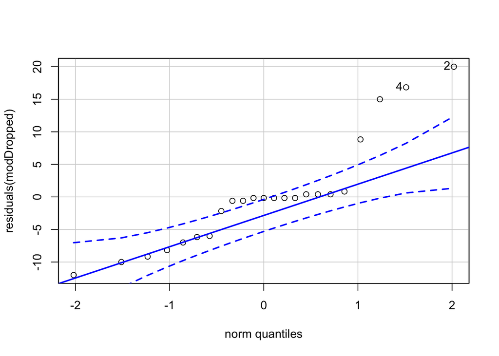

```
## [1] 2 4
```

```r
##ASSUMPTIONS
# 1. Normality of residuals
qqPlot(residuals(modDropped)) #not normal
```

```r
shapiro.test(residuals(modDropped)) #faaaiiilll
```

```
##
##  Shapiro-Wilk normality test
##
## data:  residuals(modDropped)
## W = 0.86706, p-value = 0.005636
```

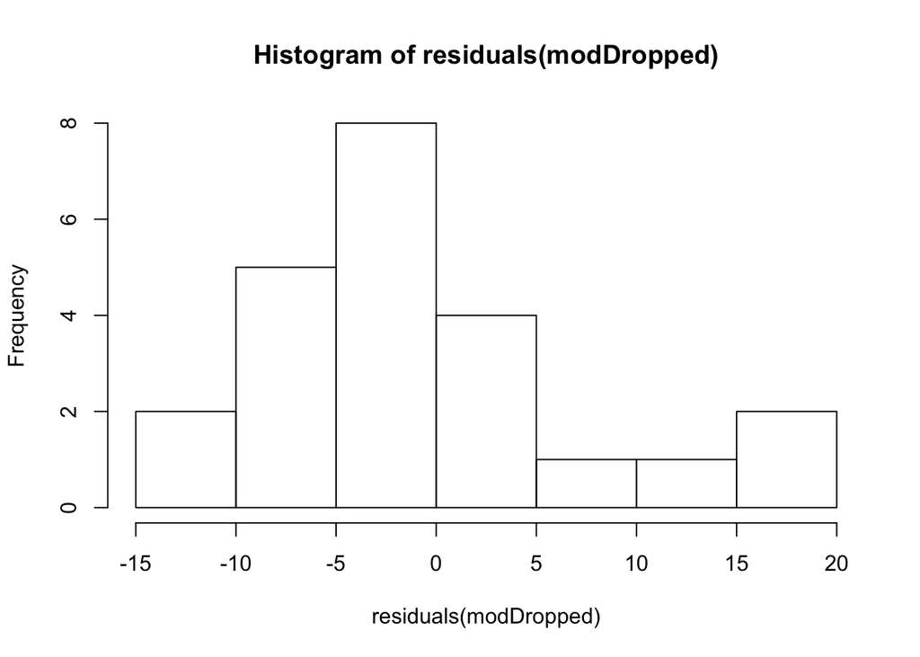

```r
hist(residuals(modDropped))
```

```r
# 2. Equal variances
leveneTest(residuals(modDropped)~resultsDropped$Treatment) # barely pass
```

```
## Levene's Test for Homogeneity of Variance (center = median)
##       Df F value  Pr(>F)
## group  3  2.8487 0.06483 .
##       19
## ---
## Signif. codes:  0 '***' 0.001 '**' 0.01 '*' 0.05 '.' 0.1 ' ' 1
```

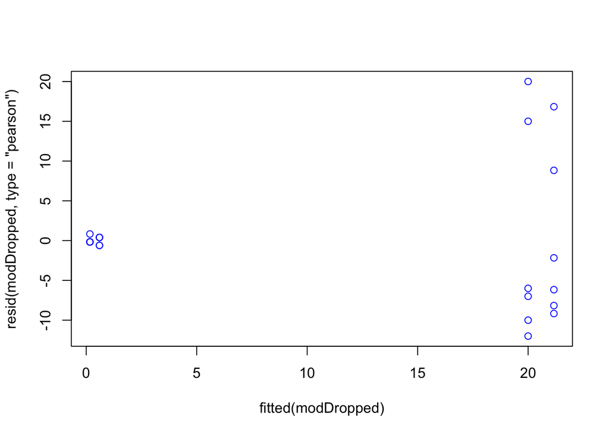

```r
plot(fitted(modDropped),resid(modDropped,type="pearson"),col="blue")
```

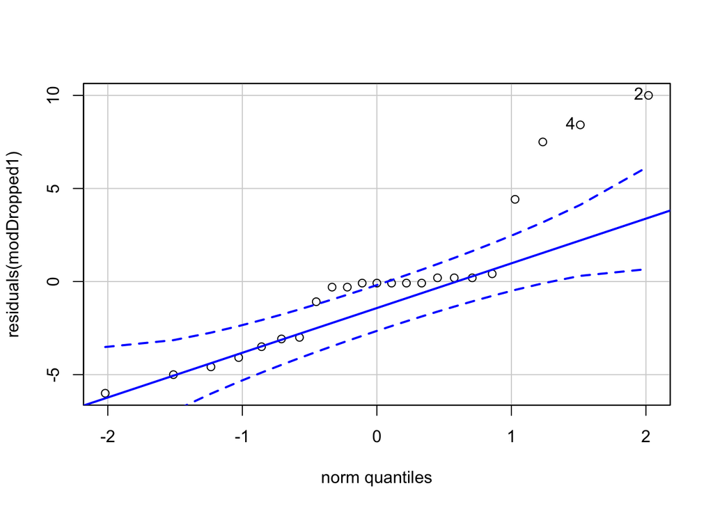

```
## [1] 2 4
```

```r
##DOES NOT MEET ASSUMPTIONS so ATTEMPT AT Transformation:
resultsDropped$tdata<-(resultsDropped$SpineCount)^1/2
  # transformation
modDropped1 <- lm(tdata~ Temperature * pH, data=resultsDropped)
  # run lm model of transformed data

###ASSUMPTIONS for Transformation
# 1. Normality of residuals
qqPlot(residuals(modDropped1)) #not normal
```

```r
shapiro.test(residuals(modDropped1)) #fail
```

```
##
##  Shapiro-Wilk normality test
##
## data:  residuals(modDropped1)
## W = 0.86706, p-value = 0.005636
```

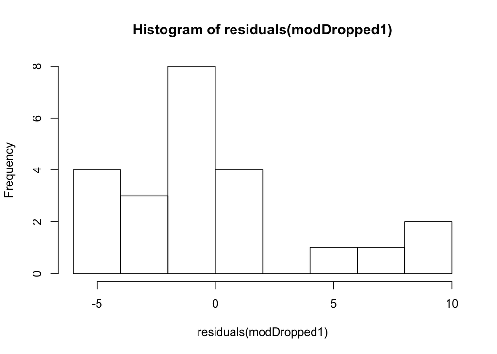

```r
hist(residuals(modDropped1))
```

```r
# 2. equal variances
bartlett.test(residuals(modDropped1)~resultsDropped$Treatment) #fail
```

```
##
##  Bartlett test of homogeneity of variances
##
## data:  residuals(modDropped1) by resultsDropped$Treatment
## Bartlett's K-squared = 43.282, df = 3, p-value = 2.144e-09
```

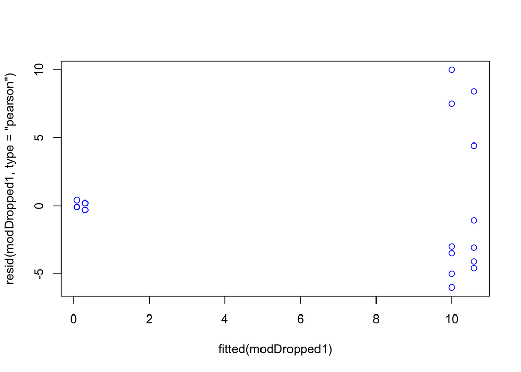

```r
plot(fitted(modDropped1),resid(modDropped1,type="pearson"),col="blue")
```

```r
summary(modDropped1)
```

```
##
## Call:
## lm(formula = tdata ~ Temperature * pH, data = resultsDropped)
##
## Residuals:
##     Min      1Q  Median      3Q     Max
## -6.0000 -3.0417 -0.0833  0.2000 10.0000
##
## Coefficients:
##                             Estimate Std. Error t value Pr(>|t|)
## (Intercept)                  10.5833     1.8202   5.814 1.33e-05 ***
## Temperatureheated            -0.5833     2.5742  -0.227  0.82315
## pHambient                   -10.5000     2.5742  -4.079  0.00064 ***
## Temperatureheated:pHambient   0.8000     3.7304   0.214  0.83248
## ---
## Signif. codes:  0 '***' 0.001 '**' 0.01 '*' 0.05 '.' 0.1 ' ' 1
##
## Residual standard error: 4.459 on 19 degrees of freedom
## Multiple R-squared:  0.6088, Adjusted R-squared:  0.547
## F-statistic: 9.855 on 3 and 19 DF,  p-value: 0.0003899
```

```r
Anova(modDropped1, type=2) #test for significance of model
```

```
## Anova Table (Type II tests)
##
## Response: tdata
##                Sum Sq Df F value    Pr(>F)
## Temperature      0.23  1  0.0118    0.9146
## pH             586.44  1 29.4995 3.062e-05 ***
## Temperature:pH   0.91  1  0.0460    0.8325
## Residuals      377.72 19
## ---
## Signif. codes:  0 '***' 0.001 '**' 0.01 '*' 0.05 '.' 0.1 ' ' 1
```

Transfomraiton (of any usual kind) of dropped spines was not successful, so we use a non parametric Kruskal Wallis Test.

```r
### Transformations not work, so use non parametric:
kruskal.test(resultsDropped$SpineCount~resultsDropped$Treatment)# SIG*** (p=0.0005563)

kruskal.test(resultsDropped$SpineCount~resultsDropped$Temperature)#
kruskal.test(resultsDropped$SpineCount~resultsDropped$pH)#
```

[output not shown]

Conduct Dunn Post Hoc Test for dropped spines

```r
## POST HOC Pairwise
dunn <-
  resultsDropped %>%
  dunnTest(SpineCount ~ Treatment,
           method = "holm", kw = TRUE, data = .)
dunnph <- dunn$res
cldList(P.adj ~ Comparison, data = dunnph, threshold = 0.05)
```

```
##   Group Letter MonoLetter
## 1   AMB      a        a
## 2    OA      b         b
## 3     T     ac        a c
## 4  T/OA     bc         bc
```

#### ii. Figure 5: Spine Loss Interaction Plot

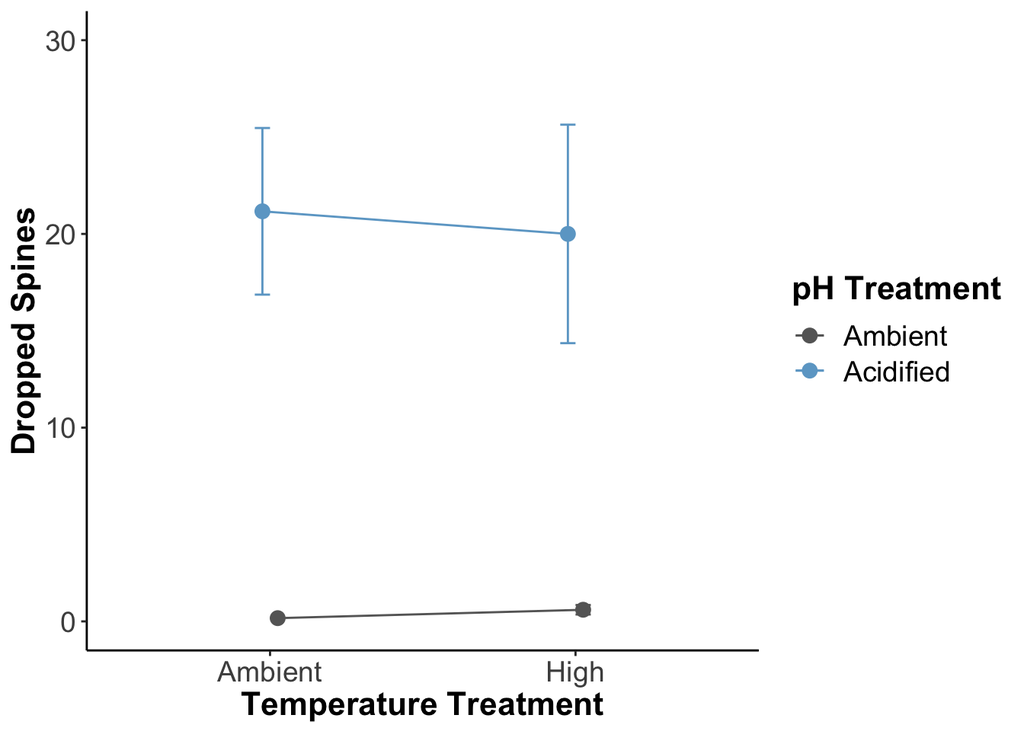

```r
droppedsummary<-results %>%
  select("Temperature","pH","SpineCount") %>%
  drop_na(SpineCount) %>%
  group_by(pH, Temperature) %>%
  summarize(mean = mean(SpineCount), se = std.error(SpineCount), N = length(SpineCount))

  dropplot<-ggplot(data=droppedsummary, aes(x=Temperature, y=mean, color = pH, group=interaction(Temperature,pH))) +
    geom_point(size = 3,  position=position_dodge(0.1)) +
    geom_line(aes(group=pH),  position=position_dodge(0.1)) +
    xlab("Temperature Treatment") +
    ylab("Dropped Spines")+
    geom_errorbar(aes(ymin = mean-se, ymax = mean+se, width = 0.1), position=position_dodge(0.1)) +
    ylim(0,30) +
    theme_bw() +
    scale_x_discrete(limits=c("ambient", "heated"),
                     label=c("Ambient", "High"))+
    scale_colour_manual(name = "pH Treatment",
                        values = c("skyblue3", "gray40"),
                        labels = c("Acidified", "Ambient"),
                        guide = guide_legend(reverse = TRUE)) +
    #geom_text(x=1.5, y=11, label="p(pH)<0.001", size=6, color="black") +
    #geom_text(x=1.5, y=9, label="p(Temperature)=0.91", size=6, color="darkgray") +
    #geom_text(x=1.5, y=7, label="p(Interaction)=0.83", size=6, color="darkgray") +
    theme_classic()+
    theme(legend.position = "right",
          legend.background = element_blank(),
          axis.title = element_text(size = 16, face="bold"),
          axis.text = element_text(size = 14),
          plot.title = element_text(size=16, face="bold"),
          legend.text = element_text(size=14),
          legend.title = element_text(size=16, face="bold"));dropplot
```

```r
#ggsave(filename="Figures/20200611/DroppedSpinesFig.png", plot=dropplot, dpi=300, width=8, height=6, units="in")
```